# Time in Program Analyses

Kirk Vanacore

9/27/2021

```r
# From Here to There
fh2t <- read.csv("FH2T_aggregation_overall_merge_2021_03_25 - Sheet1.csv",
                 na.strings = c("", "N/A"))
colnames(fh2t)

# ASSITSments
assist <- read.csv("ASSISTments_summary_merged_2021_04_23 - Sheet1.csv",
                 na.strings = c("", "N/A"))
colnames(assist)
```

# Data Cleaning

*code hidden*

## Notes on the time variables:

- The FH2T data has extreme outliers, probably due to timeout issues. We may want to go back an impose a session level timeout threshold before aggregating the data. Alternatively, we could go back to the log file data and examine when the student’s activity ceased and recalculate the session level data (last activity time - loggin time)
- I recalculated the ASSISTments aggregated time data because many of the students were missing the summative time variables. I inferred that this was because if their assignment level data was ever NA (possibly because they didn’t start the assignment) then all their summitive data is also NA. I converted the NA to zero where appropriate to reduced missingness.
- The ASSISTments data has missing time data even for students who started the sessions. I’m not sure why this would be the case.
- How where the assignment data captured? Were these self reported?

# Time

measured in minutes

## Avgerage time

### Descriptives

```r
# From Here to There
describe(fh2t$o_avg_time_session_minutes)
```

```
##    vars    n   mean      sd median trimmed  mad  min      max    range  skew
## X1    1 1183 218.47 3225.61   22.1   21.72 5.48 0.08 103430.2 103430.1 28.46
##    kurtosis    se
## X1   888.48 93.78
```

```r
# ASSISTments
describe(assist$avg_time_on_task_o_recalc)
```

```
##    vars   n  mean   sd median trimmed  mad min   max range skew kurtosis   se
## X1    1 645 18.88 6.38  19.08    18.8 5.21   0 77.97 77.97 1.85    14.99 0.25
```

Medians are comparable but From Here 2 There has an extreme postie skew.

### Outliers

```r
# From Here to There
table(scale(fh2t$o_avg_time_session_minutes) > 3)
```

```
##
## FALSE  TRUE
##  1178     5
```

```r
# z score doesn't really capture the number of outliers, I think this is because there is one that is really driving the mean up
# perhaps going back an imposing a timeout rule before aggregating may help, if we want to use this variable
table(fh2t$o_avg_time_session_minutes > 60) # 32 over two hours
```

```
##
## FALSE  TRUE
##  1151    32
```

```r
table(fh2t$o_avg_time_session_minutes > 120) # 30 over two hours
```

```
##
## FALSE  TRUE
##  1153    30
```

```r
table(fh2t$o_avg_time_session_minutes > 24*60) # 18 over 24 hours
```

```
##
## FALSE  TRUE
##  1165    18
```

```r
# ASSISTments
table(scale(assist$avg_time_on_task_o_recalc) > 2)# some outliers
```

```
##
## FALSE  TRUE
##   632    13
```

```r
table(assist$avg_time_on_task_o_recalc > 60) # 2 over one hour
```

```
##
## FALSE  TRUE
##   643     2
```

```r
table(assist$avg_time_on_task_o_recalc > 120) # no one over 2 hours
```

```
##
## FALSE
##   645
```

### Density` Plots

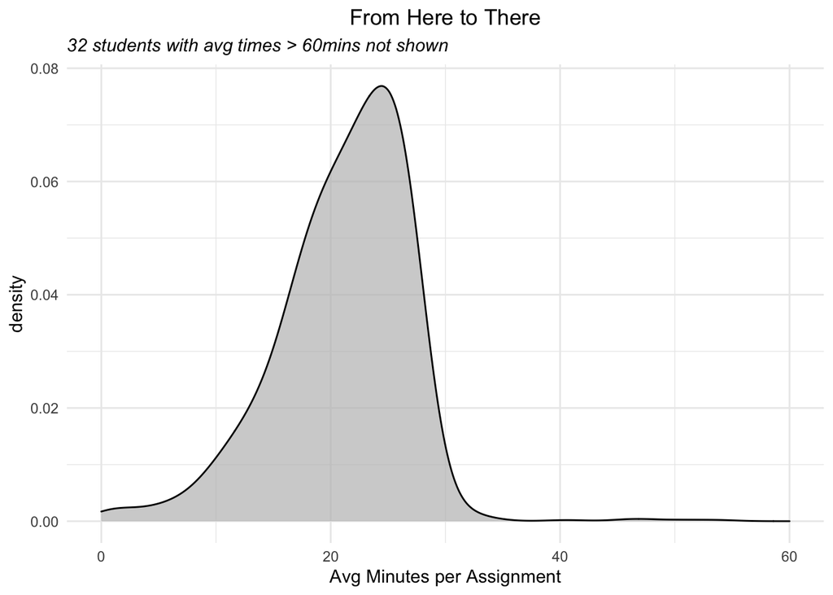

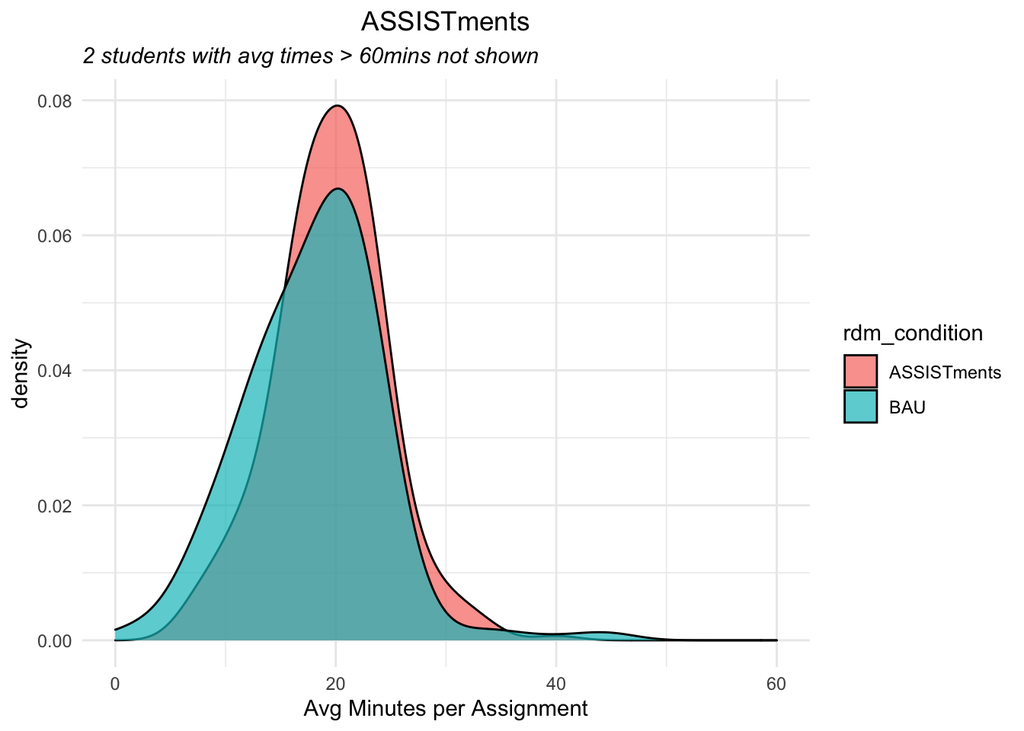

```r
ggplot(
  data = fh2t,
  aes(x = o_avg_time_session_minutes)) +
  geom_density(adjust = 1.5, alpha = .7, fill = "gray") +
  xlim(0, 60) +
  theme_minimal() +
  labs(title ="From Here to There",
       subtitle = "32 students with avg times > 60mins not shown",
       x = "Avg Minutes per Assignment") +
  theme(plot.title = element_text(hjust = 0.5),
        plot.subtitle = element_text(face = 'italic'))
ggplot(
  data = assist,
  aes(x = avg_time_on_task_o_recalc,
      group = rdm_condition,
      fill = rdm_condition)) +
  geom_density(adjust = 1.5, alpha = .7) +
  xlim(0, 60) +
  theme_minimal() +
  labs(title = "ASSISTments",
       subtitle = "2 students with avg times > 60mins not shown",
       x = "Avg Minutes per Assignment") +
  theme(plot.title = element_text(hjust = 0.5),
        plot.subtitle = element_text(face = 'italic'))
```

## Total Time

### Descriptives

```r
# From Here to There
psych::describe(fh2t$o_time_interaction_in_min)
```

```
##    vars    n   mean     sd median trimmed   mad min     max   range  skew
## X1    1 1184 148.81 226.55  135.2   131.8 89.13   0 4087.08 4087.08 11.46
##    kurtosis   se
## X1   157.82 6.58
```

```r
# ASSISTments
psych::describe(assist$sum_tot_Mins_recaclc)
```

```
##    vars   n  mean    sd median trimmed    mad min    max  range skew kurtosis
## X1    1 844 98.97 82.87 100.37   93.51 114.11   0 565.96 565.96 0.52     0.37
##      se
## X1 2.85
```

From Here to There students seem to have spent more time in the program compaired with assistment students, but this could be driven by the motive skew of these data, which could be caused with timeout issues in the way login/logout data are captured.

### Outliers

```r
# From Here to There
psych::describe(scale(fh2t$o_time_interaction_in_min) )
```

```
##    vars    n mean sd median trimmed  mad   min   max range  skew kurtosis   se
## X1    1 1184    0  1  -0.06   -0.08 0.39 -0.66 17.38 18.04 11.46   157.82 0.03
```

```r
table(scale(fh2t$o_time_interaction_in_min) > 3)
```

```
##
## FALSE  TRUE
##  1175     9
```

```r
# z score doesn't really capture the number of outliers, I think this is because there is one that is really driving the mean up
# perhaps going back an imposing a timeout rule before aggregating may help, if we want to use this variable
table(fh2t$o_time_interaction_in_min > 500)
```

```
##
## FALSE  TRUE
##  1174    10
```

```r
# ASSISTments
psych::describe(scale(assist$sum_tot_Mins_recaclc) )
```

```
##    vars   n mean sd median trimmed  mad   min  max range skew kurtosis   se
## X1    1 844    0  1   0.02   -0.07 1.38 -1.19 5.64  6.83 0.52     0.37 0.03
```

```r
table(scale(assist$sum_tot_Mins_recaclc) > 3)
```

```
##
## FALSE  TRUE
##   839     5
```

```r
table(assist$sum_tot_Mins_recaclc > 500)
```

```
##
## FALSE  TRUE
##   843     1
```

```r
table(assist$rdm_condition)
```

```
##
## ASSISTments         BAU
##         795         794
```

### Density Plots

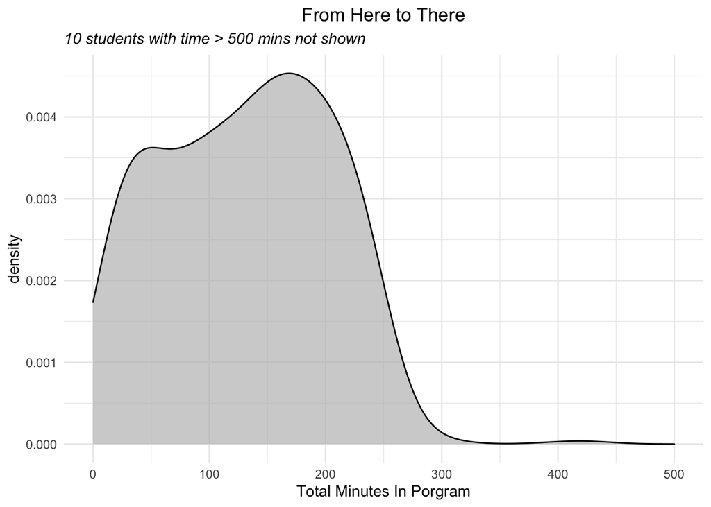

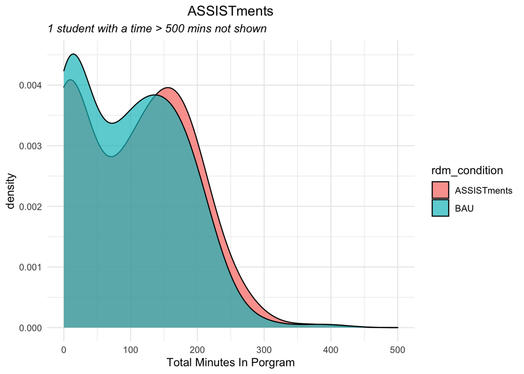

```r
ggplot(
  data = fh2t,
  aes(x = o_time_interaction_in_min)) +
  geom_density(adjust = 1.5, alpha = .7, fill = "gray") +
  xlim(0, 500) +
  theme_minimal() +
  labs(title ="From Here to There",
       subtitle = "10 students with time > 500 mins not shown",
       x = "Total Minutes In Porgram") +
  theme(plot.title = element_text(hjust = 0.5),
        plot.subtitle = element_text(face = 'italic'))
ggplot(
  data = assist[which(is.na(assist$rdm_condition) == F ),],
  aes(x = sum_tot_Mins_recaclc,
      group = rdm_condition,
      fill = rdm_condition)) +
  geom_density(adjust = 1.5, alpha = .7) +
  xlim(0, 500) +
  theme_minimal() +
  labs(title = "ASSISTments",
       subtitle = "1 student with a time > 500 mins not shown",
       x = "Total Minutes In Porgram") +
  theme(plot.title = element_text(hjust = 0.5),
        plot.subtitle = element_text(face = 'italic'))
```